# Marketing Data

What are the demographic and financial profiles of clients who subscribe to a term deposit compared to those who do not?

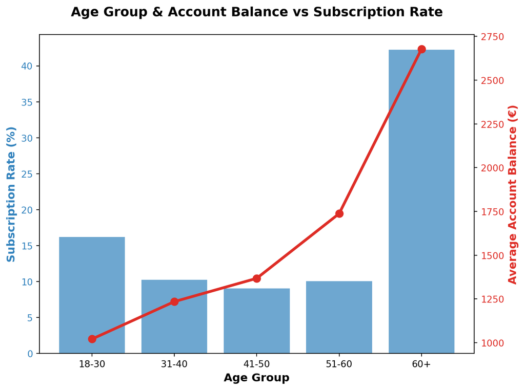

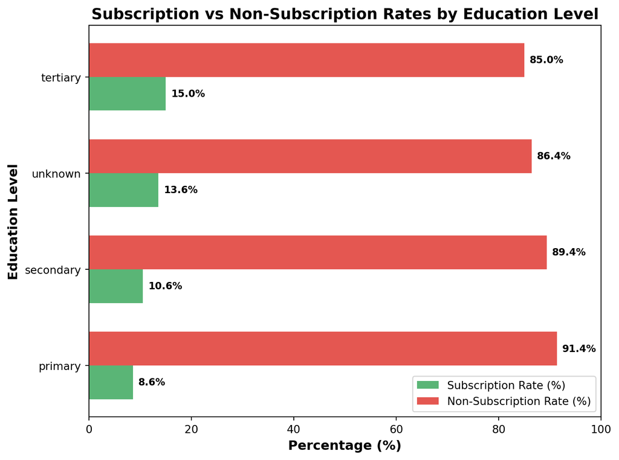

### Key Findings

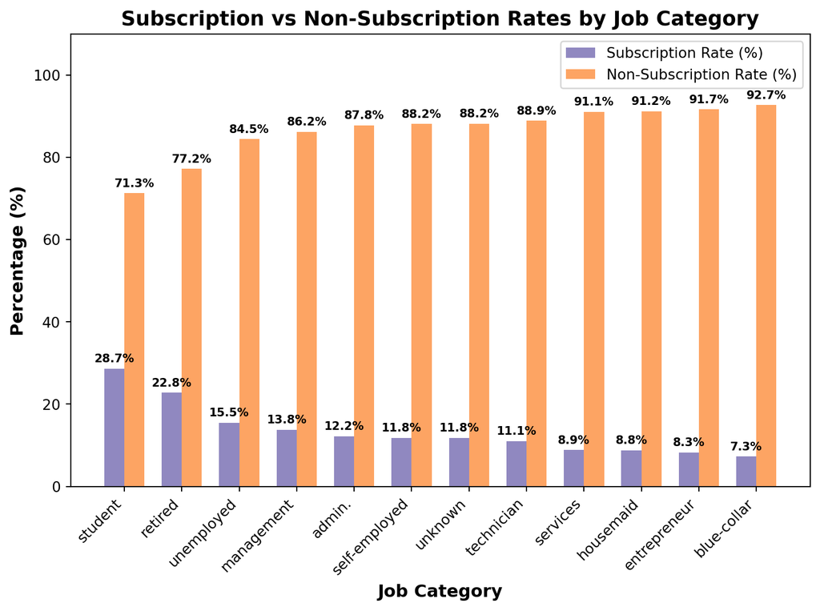

How does the strategy of the campaign correlate with success rate of subscriptions?

Day of Contact

| days | yes | no | percent |
| --- | --- | --- | --- |
| 1-7 | 1,233 | 8,565 | 12.58% |
| 8-14 | 1,377 | 9,065 | 13.19% |
| 15-21 | 1,349 | 12,551 | 9.71% |
| 22-30 | 1,284 | 9,144 | 12.31% |

Month of Contact

| month | yes | no | percent |
| --- | --- | --- | --- |
| jan | 142 | 1,261 | 10.12% |
| feb | 441 | 2,208 | 16.65% |
| mar | 248 | 229 | 51.99% |
| apr | 577 | 2,355 | 19.68% |
| may | 925 | 12,841 | 6.72% |
| jun | 546 | 4,795 | 10.22% |
| jul | 627 | 6,268 | 9.09% |
| aug | 688 | 5,559 | 11.01% |
| sep | 269 | 310 | 46.46% |
| oct | 323 | 415 | 43.77% |
| nov | 403 | 3,567 | 10.15% |
| dec | 100 | 114 | 46.73% |

Number of Contacts

| contacts | yes | no | percent |
| --- | --- | --- | --- |
| 1-10 | 5,242 | 38,773 | 11.91% |
| 11-20 | 43 | 909 | 4.52% |
| 21-30 | 3 | 182 | 1.62% |
| 31-40 | 1 | 45 | 2.17% |
| 41-50 | 0 | 9 | 0.00% |
| 51-60 | 0 | 3 | 0.00% |
| 61-70 | 0 | 1 | 0.00% |

To what extent does a client’s current loans affect their likelihood of subscribing for the current campaign?

[interactive chart not shown]

To what extent does a client’s past interaction with the bank affect their likelihood of subscribing for the current campaign?

[interactive chart not shown]

- **Baseline Classifier**
- Uses only duration variable
  - Not useful because you would have to contact the customer to know if they are willing to subscribe
- This will serve as the baseline model and the goal is to get a better-performing model
- Performance Metrics:
  - F1 Score: 0.26
  - Precision: 0.54
  - Recall: 0.17
  - Accuracy: 0.88

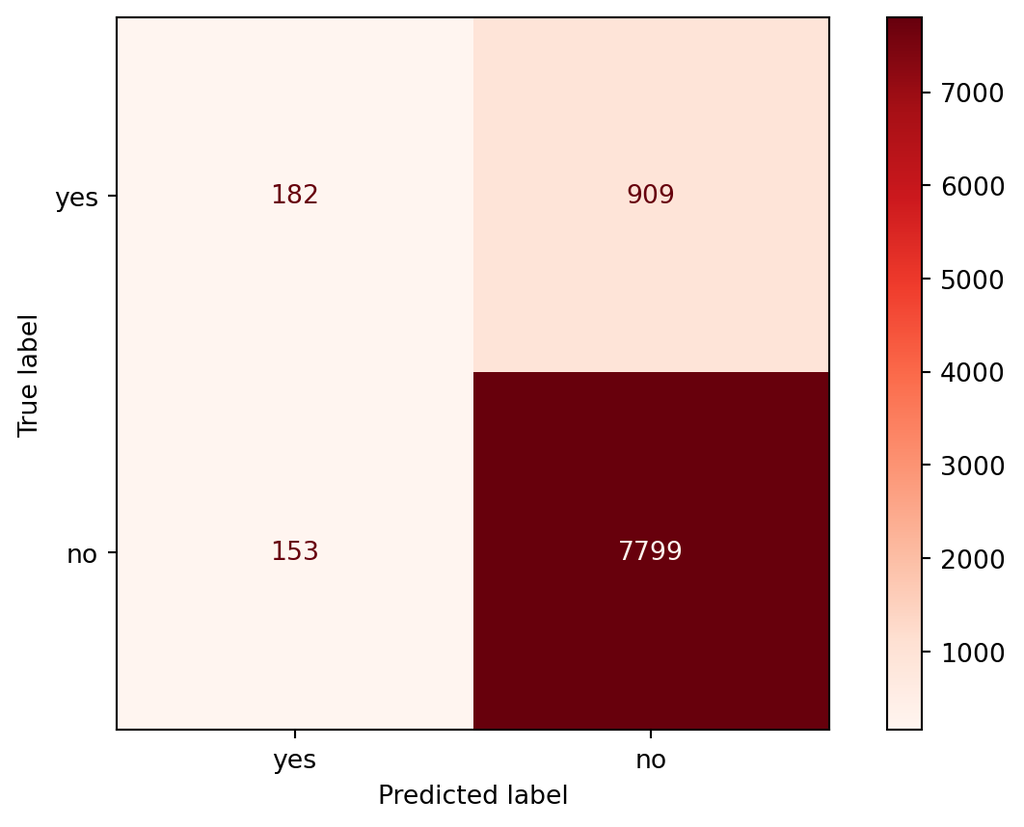

- **Gradient Boosting Classifier**
- Uses hyperparameter tuning
- Need to improve recall score
  - recall is the number of customers that were predicted as not subscribing when they actually did
- Performance Metrics:
  - F1 Score: 0.36
  - Precision: 0.61
  - Recall: 0.25
  - Accuracy: 0.89

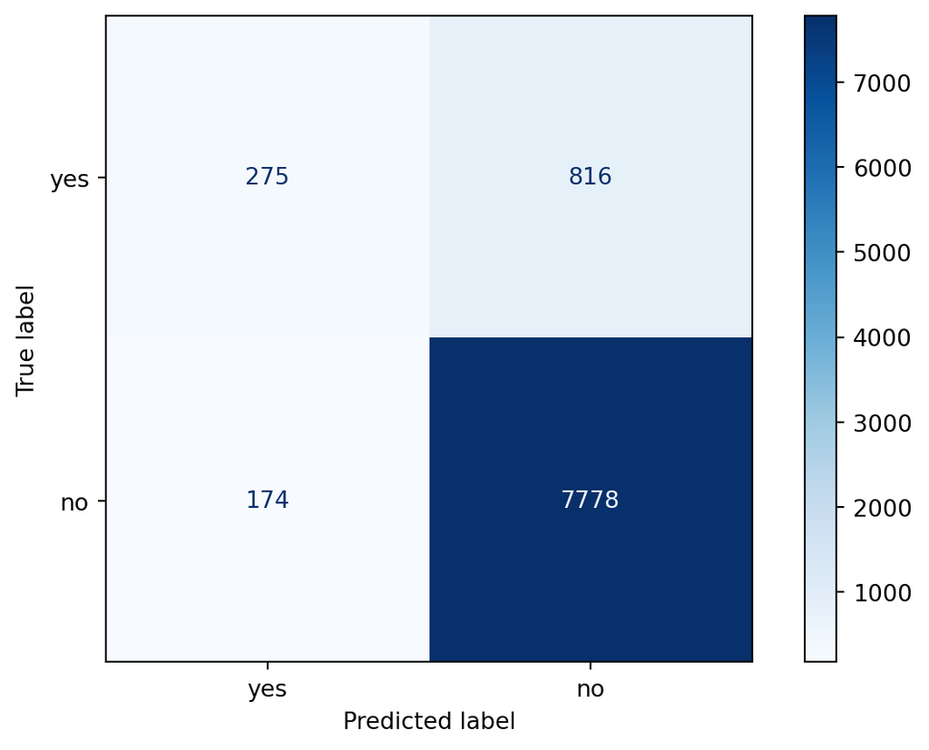

- **Final Model**
- Gradient Boosting Classifier with Smote oversampling and custom threshold of 0.25
- Slighly lower accuracy, but with an improved recall score
- Performance Metrics:
  - F1 Score: 0.47
  - Precision: 0.48
  - Recall: 0.46
  - Accuracy: 0.87

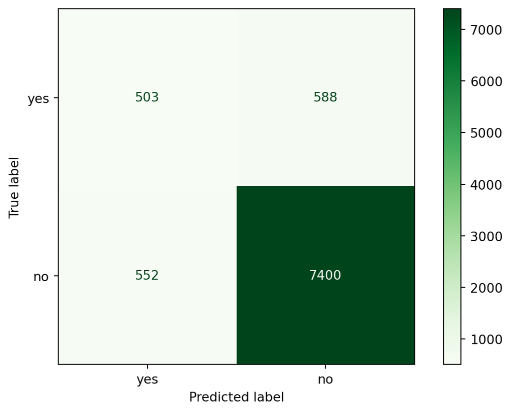

Interactive chart to explore the difference in metrics between each job with the final model

[interactive chart not shown]